# GPA and Hours of Study

This problem requires you to write answers to the following questions in an R markdown file. You will create the markdown file and an html file generated by the markdown file.

In this problem, you will analyze a combined Stat 100 and Stat 200 survey data in Spring 2017 to determine if a student’s GPA is correlated with the average number of hours the student spend studying.

First, download the csv file of the data [here](https://ytliu0.github.io/Stat390EF-R-Independent-Study-archive/RMarkdownExercises/Stat100_200_2017spring_survey01M.csv) and save it as “Stat100_200_2017spring_survey01M.csv” to the folder where your R markdown file is. Load the file to R using the command

```r
survey <- read.csv("Stat100_200_2017spring_survey01M.csv")
```

The description of the variables in the data frame can be found on [this webpage](https://ytliu0.github.io/Stat390EF-R-Independent-Study-archive/RMarkdownExercises/Stat100_200_2017spring_survey01M.html). Take some time to explore the data.

**a. (2 points) How many students in the data are freshmen? How many of them are sophomores? How many are juniors? How many are seniors?**

**Hint: You only need a single R command to get all the answers. If you forget the command, review Week 5’s notes.**

```r
# load data
survey <- read.csv("Stat100_200_2017spring_survey01M.csv")
```

We can use the `table()` command to find out the number of students in each school year.

```r
(tbl <- table(survey$schoolYear))
```

```
 Freshman    Junior    Senior Sophomore
      906       159        87       351
```

We see that there are 906 freshmen, 351 sophomores, 159 juniors and 87 seniors.

**b. (2 points) Use the `xyplot()` function in the lattice graphics to make scatter plots of the GPA versus the average study hours (in column `studyHr`) for students in each school year.**

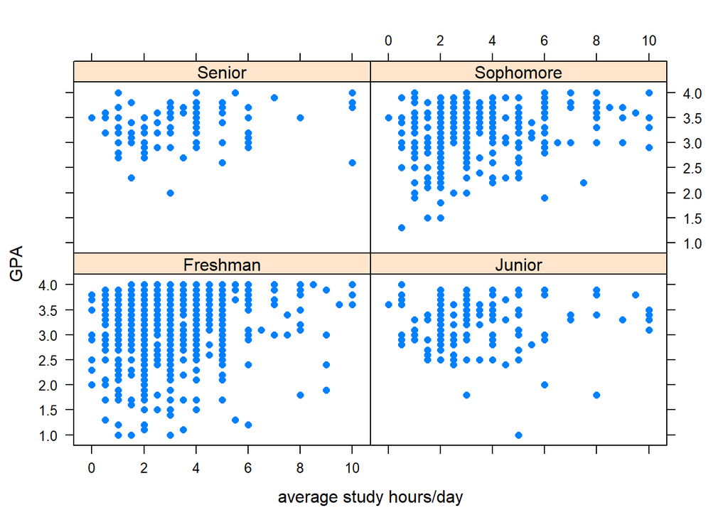

```r
# load the lattice package
library(lattice)

# create plots
xyplot(GPA ~ studyHr | schoolYear, data=survey, pch=16, xlab="average study hours/day")
```

**c. (6 points) Fit a linear model predicting a student’s GPA from the average study hours. What are the intercept and slope? Is the slope statistically significant (assume the usual null cutoff $\alpha$ = 5%)? Make a scatter plot of GPA versus studyHr and then add the regression line on the plot.**

```r
# fit linear model
fit <- lm(GPA ~ studyHr, data=survey)
summary(fit)
```

```
Call:
lm(formula = GPA ~ studyHr, data = survey)

Residuals:
    Min      1Q  Median      3Q     Max
-2.3360 -0.2892  0.1109  0.4108  0.8748

Coefficients:
            Estimate Std. Error t value Pr(>|t|)
(Intercept) 3.101772   0.027608 112.352  < 2e-16 ***
studyHr     0.046845   0.007569   6.189 7.78e-10 ***
---
Signif. codes:  0 '***' 0.001 '**' 0.01 '*' 0.05 '.' 0.1 ' ' 1

Residual standard error: 0.5602 on 1501 degrees of freedom
Multiple R-squared:  0.02489,   Adjusted R-squared:  0.02424
F-statistic: 38.31 on 1 and 1501 DF,  p-value: 7.783e-10
```

From the summary output, we see that the intercept is 3.102 and the slope is 0.04685. The p-value for the slope is 7.78×10<sup>-10</sup> << 5%. This means that the slope is highly significant.

The scatter plot and regression line (thick red line) is plotted below.

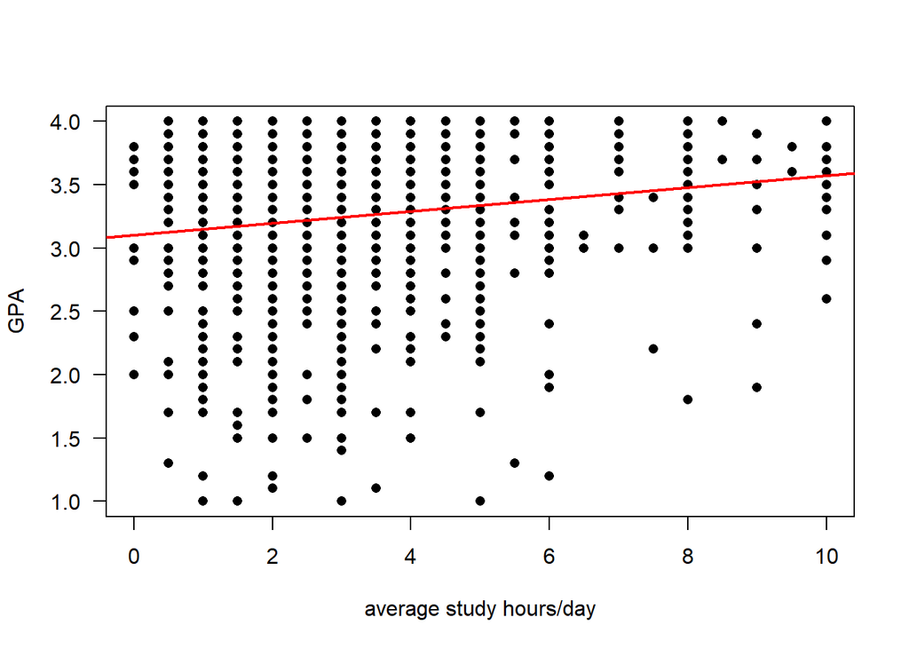

```r
plot(GPA ~ studyHr, data=survey, las=1, pch=16, xlab="average study hours/day")
abline(fit, col="red", lwd=2)
```

**d. (2 points) Based on the result in part (c), what can you conclude about the relationship of GPA and average study hours?**

Since the slope is positive and is highly significant, there is evidence to suggest an assoication between a student who spends more hours studying and having a higher GPA. There is a positive correlation between the average study hours and GPA.

However, the correlation coefficient between the GPA and study hour is 0.16 (computed by the command `cor(survey$GPA,survey$studyHr)`). This is not a strong correlation.

**e. (2 points) Make a scatter plot of the residuals versus studyHr for the regression result in part (c).**

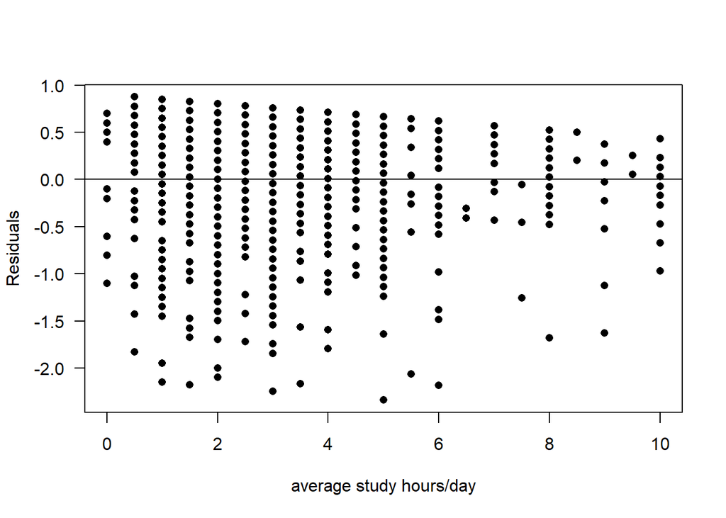

```r
# Residual plot for part (c)
plot(fit$residuals ~ survey$studyHr, xlab="average study hours/day",
     ylab="Residuals", las=1, pch=16)
abline(h=0)
```

**f. (9 points) Create 4 subsets of the survey data frame containing freshman, sophomore, junior and senior students. Then fit a linear model predicting GPA from studyHr for each group. The slope of which group(s) is significant at the 5% level?**

**Hint: If you forget how to subset a data frame, review Week 3’s Lon Capa problem on subsetting a data frame.**

```r
# subset data
survey_fr <- survey[survey$schoolYear=="Freshman",]
survey_so <- survey[survey$schoolYear=="Sophomore",]
survey_jr <- survey[survey$schoolYear=="Junior",]
survey_sr <- survey[survey$schoolYear=="Senior",]

# fit linear models
fit_fr <- lm(GPA ~ studyHr, data=survey_fr)
fit_so <- lm(GPA ~ studyHr, data=survey_so)
fit_jr <- lm(GPA ~ studyHr, data=survey_jr)
fit_sr <- lm(GPA ~ studyHr, data=survey_sr)

# look at the models
summary(fit_fr)
```

```
Call:
lm(formula = GPA ~ studyHr, data = survey_fr)

Residuals:
    Min      1Q  Median      3Q     Max
-2.2671 -0.2841  0.1436  0.4436  0.8159

Coefficients:
            Estimate Std. Error t value Pr(>|t|)
(Intercept)  3.10100    0.03984  77.832  < 2e-16 ***
studyHr      0.05537    0.01160   4.774 2.11e-06 ***
---
Signif. codes:  0 '***' 0.001 '**' 0.01 '*' 0.05 '.' 0.1 ' ' 1

Residual standard error: 0.606 on 904 degrees of freedom
Multiple R-squared:  0.02459,   Adjusted R-squared:  0.02351
F-statistic: 22.79 on 1 and 904 DF,  p-value: 2.108e-06
```

```r
summary(fit_so)
```

```
Call:
lm(formula = GPA ~ studyHr, data = survey_so)

Residuals:
     Min       1Q   Median       3Q      Max
-1.75128 -0.28474  0.06188  0.37861  0.92203

Coefficients:
            Estimate Std. Error t value Pr(>|t|)
(Intercept)  3.02458    0.04850  62.367  < 2e-16 ***
studyHr      0.05338    0.01251   4.268 2.55e-05 ***
---
Signif. codes:  0 '***' 0.001 '**' 0.01 '*' 0.05 '.' 0.1 ' ' 1

Residual standard error: 0.492 on 349 degrees of freedom
Multiple R-squared:  0.04959,   Adjusted R-squared:  0.04687
F-statistic: 18.21 on 1 and 349 DF,  p-value: 2.55e-05
```

```r
summary(fit_jr)
```

```
Call:
lm(formula = GPA ~ studyHr, data = survey_jr)

Residuals:
     Min       1Q   Median       3Q      Max
-2.23174 -0.29400  0.08602  0.38602  0.80822

Coefficients:
            Estimate Std. Error t value Pr(>|t|)
(Intercept)  3.18734    0.07359  43.312   <2e-16 ***
studyHr      0.00888    0.01837   0.483    0.629
---
Signif. codes:  0 '***' 0.001 '**' 0.01 '*' 0.05 '.' 0.1 ' ' 1

Residual standard error: 0.4875 on 157 degrees of freedom
Multiple R-squared:  0.001486,  Adjusted R-squared:  -0.004874
F-statistic: 0.2337 on 1 and 157 DF,  p-value: 0.6295
```

```r
summary(fit_sr)
```

```
Call:
lm(formula = GPA ~ studyHr, data = survey_sr)

Residuals:
     Min       1Q   Median       3Q      Max
-1.29268 -0.24557  0.02508  0.31311  0.80153

Coefficients:
            Estimate Std. Error t value Pr(>|t|)
(Intercept)  3.15137    0.07858  40.102   <2e-16 ***
studyHr      0.04710    0.01906   2.472   0.0154 *
---
Signif. codes:  0 '***' 0.001 '**' 0.01 '*' 0.05 '.' 0.1 ' ' 1

Residual standard error: 0.402 on 85 degrees of freedom
Multiple R-squared:  0.06706,   Adjusted R-squared:  0.05609
F-statistic:  6.11 on 1 and 85 DF,  p-value: 0.01544
```

From the summaries, we see that the slopes for the freshmen, sophomores and seniors are significant at the 5% level.

**g. (2 points) Use the `predict()` function on one of the linear models in (f) to predict the GPA of a senior student spending 1.5 hours/day studying.**

```r
(GPA_pred <- predict(fit_sr, newdata=data.frame(studyHr=1.5)))
```

```
       1
3.222022
```

So the predicted GPA is 3.22.

**h. (4 points) Fit a linear model predicting studyHr from GPA for the senior students. Then use it and the `predict()` function to predict studyHr for a senior student with a GPA = GPA_g, where GPA_g is the predicted GPA calculated in part (g) above. Is the predicted value of studyHr greater than, equal to, or smaller than 1.5?**

**(As you’ve learned in Stat 100, this phenomenon is a consequence of the *regression to the mean*.)**

```r
# linear model
fit_hours <- lm(studyHr ~ GPA, data=survey_sr)

# make prediction
(studyHr_pred <- predict(fit_hours, newdata=data.frame(GPA=GPA_pred)))
```

```
       1
3.317619
```

We see that the predicted studyHr is 3.32, which is greater than 1.5.

The predicted studyHr, 3.32, is closer to the mean of `survey_sr$studyHr` (= 3.4482759) than 1.5 is to the mean, a consequence of the *regression to the mean*.